# Project Description

This project aims to create a pipeline for image processing to detect lane lines based on camera images. The code below has been broken into different subsections, with each representing a function for the lane-finding algorithm. The pipeline can be broken down into the following sequence:

1. Camera calibration: Calibrating the camera for distortion correction
2. Perspective transform: Unwarping the image to transform the camera perspective into a bird's eye view of the lane lines for lane detection
3. Lane finding: Passing the image through selected colorspaces to identify the color thresholds of pixels for lane detection. This step will output a black and white image for the next step
4. Sliding window search: Taking in a black and white image from the previous step to perform a sliding window convolution to search for the lane lines
5. Polynomial fitting: Perform polynomial fitting to calculate the curvature of lane lines and extrapolate

```python
%matplotlib inline
import pandas as pd
import numpy as np
import matplotlib.pyplot as plt
import matplotlib.image as mpimg
import cv2
import pickle
import glob
from moviepy.editor import VideoFileClip
from IPython.display import HTML

plt.rcParams["figure.figsize"] = [15,9]
```

## 1. Camera Calibration

This part of the code serves as the pipeline for the camera calibration to correct distortion

```python
# prepare object and image points for undistortion
nx = 9#TODO: enter the number of inside corners in x
ny = 6#TODO: enter the number of inside corners in y

# Make a list of calibration images
images = glob.glob('camera_cal/calibration*.jpg')

# Arrays to store object points and image points from all the images.
objpoints = [] # 3d points in real world space
imgpoints = [] # 2d points in image plane.

# prepare object points, like (0,0,0), (1,0,0), (2,0,0) ....,(6,5,0)
objp = np.zeros((6*9,3), np.float32)
objp[:,:2] = np.mgrid[0:9,0:6].T.reshape(-1,2)

# Step through the list and search for chessboard corners
for fname in images:
    img = cv2.imread(fname)
    gray = cv2.cvtColor(img,cv2.COLOR_BGR2GRAY)

    # Find the chessboard corners
    ret, corners = cv2.findChessboardCorners(gray, (9,6),None)

    # If found, add object points, image points
    if ret == True:
        objpoints.append(objp)
        imgpoints.append(corners)
```

```python
#Function definition for undistortion
def cal_undistort(img, objpoints, imgpoints):
    gray = cv2.cvtColor(img,cv2.COLOR_BGR2GRAY)
    ret, mtx, dist, rvecs, tvecs = cv2.calibrateCamera(objpoints,
    imgpoints, gray.shape[::-1], None, None)
    undist = cv2.undistort(img, mtx, dist, None, mtx)

    return undist
```

## 2. Perspective Transform

This section of code adds the perspective transform to unwarp the lane line images. The main function of code performing the unwarp is in the unwarp function definition, while the parameters are fine-tuned in src and dst lists 2 kernels below. There is also a rewarp function to rewarp the frames from the camera images later.

```python
def unwarp(img, src, dst):
    M = cv2.getPerspectiveTransform(src, dst)
    img_size = (img.shape[1], img.shape[0])
    warped = cv2.warpPerspective(img, M, img_size, flags=cv2.INTER_LINEAR)

    return warped
```

```python
def rewarp(img, src, dst):
    M_inv = cv2.getPerspectiveTransform(dst, src)
    img_size = (image.shape[1], image.shape[0])
    rewarped = cv2.warpPerspective(img, M_inv, img_size, flags = cv2.INTER_LINEAR)
```

# 3. Lane Lines Identification (Part 1)

This section of code explores different types of color channels which would produce the most distinct results for identifying a lane. Several color spaces and methods were explored, namely:

1. Lane detecton using the Sobel Operator
2. Checking R threshold in the RGB colorspace
3. Checking the L and S thresholds in the HLS colorspace
4. Checking the Y threshold in the YUV colorspace
5. Checking the intensity threshold on a grayscale

```python
#Function to identify lane lines from unwarped image
def lanes_bw(img):
    R = img[:,:,2]
    luv = cv2.cvtColor(img, cv2.COLOR_BGR2LUV)
    lab = cv2.cvtColor(img, cv2.COLOR_BGR2LAB)

    L = luv[:,:,0]
    B = lab[:,:,2]

    if np.max(B) > 130:
        B = B*(255/np.max(B))

    l_thresh = (225, 255)
    b_thresh = (190, 255)

    binary_l = np.zeros_like(L)
    binary_b = np.zeros_like(B)

    binary_l[(L >= l_thresh[0]) & (L <= l_thresh[1])] = 1
    binary_b[(B >= b_thresh[0]) & (B <= b_thresh[1])] = 1

    return binary_l + binary_b
```

# 4. Lane Lines Identification (Part 2)

After passing through the different channels to identify the lane lines, this section will perform lane detection through the sliding window convolution method. The parameters to be tuned are the height and width of the sliding window, as well as the search margin of the window.

```python
def find_lane(binary_img):
    # Take a histogram of the bottom half of the image
    histogram = np.sum(binary_img[0:binary_img.shape[0]//2,:], axis=0)

    # Find the peak of the left and right halves of the histogram
    # These will be the starting point for the left and right lines
    midpoint = np.int(histogram.shape[0]//2)
    leftx_base = np.argmax(histogram[:midpoint])
    rightx_base = np.argmax(histogram[midpoint:]) + midpoint

    # Choose the number of sliding windows
    nwindows = 12
    # Set height of windows
    window_height = np.int(binary_img.shape[0]//nwindows)
    # Identify the x and y positions of all nonzero pixels in the image
    nonzero = binary_img.nonzero()
    nonzeroy = np.array(nonzero[0])
    nonzerox = np.array(nonzero[1])
    # Current positions to be updated for each window
    leftx_current = leftx_base
    rightx_current = rightx_base
    # Set the width of the windows +/- margin
    margin = 80
    # Set minimum number of pixels found to recenter window
    minpix = 40
    # Create empty lists to receive left and right lane pixel indices
    left_lane_inds = []
    right_lane_inds = []

    # Step through the windows one by one
    for window in range(nwindows):
        # Identify window boundaries in x and y (and right and left)
        win_y_low = binary_img.shape[0] - (window+1)*window_height
        win_y_high = binary_img.shape[0] - window*window_height
        win_xleft_low = leftx_current - margin
        win_xleft_high = leftx_current + margin
        win_xright_low = rightx_current - margin
        win_xright_high = rightx_current + margin

        # Identify the nonzero pixels in x and y within the window
        good_left_inds = ((nonzeroy >= win_y_low) & (nonzeroy < win_y_high) &
        (nonzerox >= win_xleft_low) &  (nonzerox < win_xleft_high)).nonzero()[0]
        good_right_inds = ((nonzeroy >= win_y_low) & (nonzeroy < win_y_high) &
        (nonzerox >= win_xright_low) &  (nonzerox < win_xright_high)).nonzero()[0]

        # Append these indices to the lists
        left_lane_inds.append(good_left_inds)
        right_lane_inds.append(good_right_inds)

        # If you found > minpix pixels, recenter next window on their mean position
        if len(good_left_inds) > minpix:
            leftx_current = np.int(np.mean(nonzerox[good_left_inds]))
        if len(good_right_inds) > minpix:
            rightx_current = np.int(np.mean(nonzerox[good_right_inds]))

    # Concatenate the arrays of indices
    left_lane_inds = np.concatenate(left_lane_inds)
    right_lane_inds = np.concatenate(right_lane_inds)

    # Extract left and right line pixel positions
    leftx = nonzerox[left_lane_inds]
    lefty = nonzeroy[left_lane_inds]
    rightx = nonzerox[right_lane_inds]
    righty = nonzeroy[right_lane_inds]

    # Fit a second order polynomial to each
    left_fit = np.polyfit(lefty, leftx, 2)
    right_fit = np.polyfit(righty, rightx, 2)


    return left_fit, right_fit, left_lane_inds, right_lane_inds
```

# 5. Superimposing Results with Image

This section builds the function to superimpose the results obtained earlier into the image and unwarp

```python
def draw_data(original_img, curv_rad, center_dist):

    result = np.copy(original_img)
    h = result.shape[0]
    font = cv2.FONT_HERSHEY_PLAIN
    text = 'Curve radius: ' + '{:04.2f}'.format(curv_rad) + 'm'
    cv2.putText(result, text, (40,70), font, 1.5, (200,255,155), 2, cv2.LINE_AA)
    direction = ''
    if center_dist > 0:
        direction = 'right'
    elif center_dist < 0:
        direction = 'left'
    abs_center_dist = abs(center_dist)
    text = '{:04.3f}'.format(abs_center_dist) + 'm ' + direction + ' of center'
    cv2.putText(result, text, (40,120), font, 1.5, (200,255,155), 2, cv2.LINE_AA)
    return result
```

# 6. Image pipeline

Function definition to return an image through the processing pipeline.

In order to run this function, the camera calibration needs to be run beforehand in order to obtain saved values of objpoints and imgpoints

```python
#Need to run camera cal before running this
def pipeline(img):

        y = 450
        h = img.shape[0]
        w = img.shape[1]

        src = np.float32([(300, 680), (600, 450), (980, 680), (680, 450)])
        dst = np.float32([(y, 0), (y, h), (w-y, 0), (w-y, h)])

        pic = cal_undistort(img, objpoints, imgpoints)
        pic = unwarp(pic, src, dst)
        binary_img = lanes_bw(pic)

        try:
            left_fit, right_fit, left_lane_inds, right_lane_inds = find_lane(binary_img)

        except:
            left_fit = l_line.current_fit
            right_fit = r_line.current_fit
            left_lane_inds = l_line.inds
            right_lane_inds = r_line.inds
            binary_img = l_line.binary_img

        nonzero = binary_img.nonzero()
        nonzeroy = np.array(nonzero[0])
        nonzerox = np.array(nonzero[1])

        # Extract left and right line pixel positions
        leftx = nonzerox[left_lane_inds]
        lefty = nonzeroy[left_lane_inds]
        rightx = nonzerox[right_lane_inds]
        righty = nonzeroy[right_lane_inds]

        # Fit a second order polynomial to each
        left_fit = np.polyfit(lefty, leftx, 2)
        right_fit = np.polyfit(righty, rightx, 2)

        # Generate x and y values for plottingmg
        ploty = np.linspace(0, binary_img.shape[0]-1, binary_img.shape[0] )

        # Define conversions in x and y from pixels space to meters
        ym_per_pix = 30/720 # meters per pixel in y dimension
        xm_per_pix = 3.7/700 # meters per pixel in x dimension

        left_fit_cr = np.polyfit(lefty*ym_per_pix, leftx*xm_per_pix, 2)
        right_fit_cr = np.polyfit(righty*ym_per_pix, rightx*xm_per_pix, 2)

        # Calculate the new radii of curvature
        y_eval = np.max(ploty)
        left_curverad = ((1 + (2*left_fit_cr[0]*y_eval*ym_per_pix + left_fit_cr[1])**2)**1.5) / np.absolute(2*left_fit_cr[0])
        right_curverad = ((1 + (2*right_fit_cr[0]*y_eval*ym_per_pix + right_fit_cr[1])**2)**1.5) / np.absolute(2*right_fit_cr[0])

        curve_rad = 0.5*(left_curverad + right_curverad)

        h = img.shape[0]
        w = img.shape[1]

        if right_fit is not None and left_fit is not None:
                car_position = w/2
                l_fit_x_int = left_fit[0]*h**2 + left_fit[1]*h + left_fit[2]
                r_fit_x_int = right_fit[0]*h**2 + right_fit[1]*h + right_fit[2]
                lane_center_position = (r_fit_x_int + l_fit_x_int) /2
                center_dist = (car_position - lane_center_position) * xm_per_pix
                x_int_diff = r_fit_x_int - l_fit_x_int

                l_line.current_fit = left_fit
                r_line.current_fit = right_fit
                l_line.inds = left_lane_inds
                r_line.inds = right_lane_inds
                l_line.binary_img = binary_img

        #Reformat plot_left and plot_right into vertices
        left_fitx = left_fit[0]*ploty**2 + left_fit[1]*ploty + left_fit[2]
        right_fitx = right_fit[0]*ploty**2 + right_fit[1]*ploty + right_fit[2]

        blank = np.zeros_like(img)
        pts_left = np.array([np.transpose(np.vstack([left_fitx, ploty]))])
        pts_right = np.array([np.flipud(np.transpose(np.vstack([right_fitx, ploty])))])
        pts = np.hstack((pts_left, pts_right))

        # Draw the lane onto the warped blank image
        cv2.fillPoly(blank, np.int_([pts]), (0, 255, 0))
        cv2.polylines(blank, np.int32([pts_left]), isClosed=False, color=(0,0,255), thickness=15)
        cv2.polylines(blank, np.int32([pts_right]), isClosed=False, color=(0,0,255), thickness=15)

        # Warp the blank back to original image space using inverse perspective matrix (Minv)
        newwarp = unwarp(blank, dst, src)

        # Combine the result with the original image
        result = cv2.addWeighted(img, 1, newwarp, 0.5, 0)
        result = draw_data(result, curve_rad, center_dist)

        return result
```

```python
def process_image(img):

    pic_drawn = pipeline(img, objpoints, imgpoints)

    return pic_drawn
```

```python
class Line():
    def __init__(self):
        # was the line detected in the last iteration?
        self.detected = False
        # x values of the last n fits of the line
        self.recent_xfitted = []
        #average x values of the fitted line over the last n iterations
        self.bestx = None
        #polynomial coefficients averaged over the last n iterations
        self.best_fit = None
        #polynomial coefficients for the most recent fit
        self.current_fit = [np.array([False])]
        #radius of curvature of the line in some units
        self.radius_of_curvature = None
        #distance in meters of vehicle center from the line
        self.line_base_pos = None
        #difference in fit coefficients between last and new fits
        self.diffs = np.array([0,0,0], dtype='float')
        #x values for detected line pixels
        self.allx = None
        #y values for detected line pixels
        self.ally = None
        #stores the indices of the found pixels
        self.inds = None
        self.binary_img = None
```

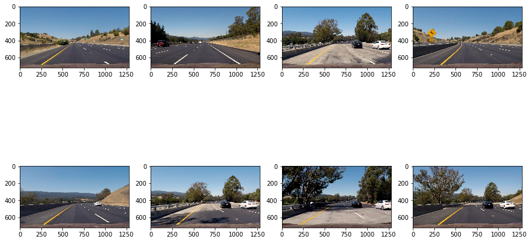

```python
test_image_names =  ['test_images/straight_lines1.jpg',
               'test_images/straight_lines2.jpg',
               'test_images/test1.jpg',
               'test_images/test2.jpg',
               'test_images/test3.jpg',
               'test_images/test4.jpg',
               'test_images/test5.jpg',
               'test_images/test6.jpg']
test_images = []
fig = plt.figure()
for i in range(len(test_image_names)):
    curr = cv2.imread(test_image_names[i])
    test_images.append(curr)


    fig.add_subplot(2, 4, i+1)
    plt.imshow(cv2.cvtColor(test_images[i], cv2.COLOR_BGR2RGB))
```

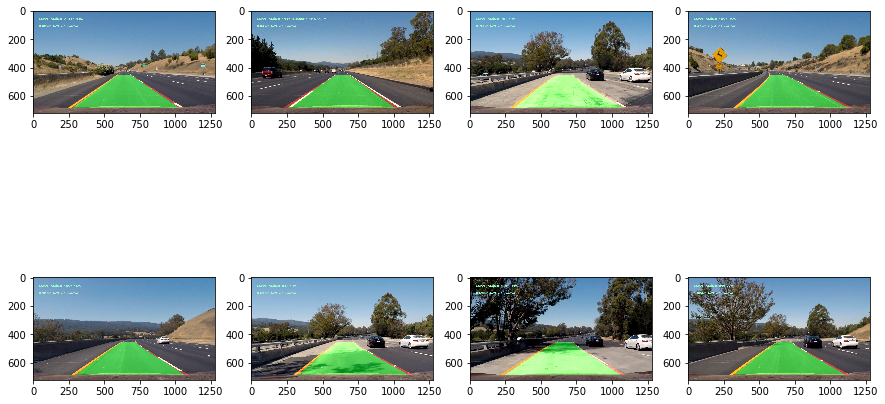

```python
fig = plt.figure()
for i in range(len(test_image_names)):
    result = pipeline(test_images[i])

    fig.add_subplot(2, 4, i+1)
    plt.imshow(cv2.cvtColor(result, cv2.COLOR_BGR2RGB))

fig.savefig("output.jpg")
```

# 8. Project Video

This section inputs the sample video through the pipeline and produces the output project video

```python
l_line = Line()
r_line = Line()
```

```python
def process(img):

    img = cv2.cvtColor(img, cv2.COLOR_RGB2BGR)
    result = pipeline(img)
    result = cv2.cvtColor(result, cv2.COLOR_BGR2RGB)
    return result
```

```python
white_output = 'project_output.mp4'
clip1 = VideoFileClip("project_video.mp4")
white_clip = clip1.fl_image(process) #NOTE: this function expects color images!!
%time white_clip.write_videofile(white_output, audio=False)
HTML("""
<video width="1280" height="720" controls>
  <source src="{0}">
</video>
""".format("project_output.mp4"))
```

```
[MoviePy] >>>> Building video project_output.mp4
[MoviePy] Writing video project_output.mp4
```

```
[MoviePy] Done.
[MoviePy] >>>> Video ready: project_output.mp4

CPU times: user 18min 57s, sys: 2.31 s, total: 18min 59s
Wall time: 14min 14s
```

[video not shown]